# Jornada de introducción a la Genómica y la Bioinformática

Machine learning y bioinformática: análisis de componentes principales

Profesor: Carlos Pérez-Glez (departamento de Matemáticas, Estadística e Investigación Operativa)

Junio, 2019

[interactive chart not shown]

# Análisis de los individuos/observaciones en PCA

# Las coordenadas, calidad y contribución de las observaciones en las CPs

- Para obtener las coordenadas de las observaciones en las CPs vemos

```r
res.pca3$ind$coord   # puntuaciones factoriales
```

```
##              Dim.1      Dim.2      Dim.3       Dim.4
## tumor_a -0.8077113  1.9343199 -0.2877048 -0.24634795
## tumor_b -1.2807803  1.7543961  0.4831515 -0.42479725
## tumor_c -0.9232763  2.2439025 -0.4177970  0.56527325
## tumor_d -2.2531967 -1.3619120  0.4580948  0.39285885
## tumor_e -2.3409193 -1.7035043 -0.9923015 -0.38499467
## tumor_f -2.2247307 -1.5032677  0.4482729  0.11169530
## tumor_g  3.1202644 -0.6386387  0.3225145 -0.04507721
## tumor_h  2.9965035 -0.2323599  1.7372830 -0.04930481
## tumor_i  3.7138469 -0.4929359 -1.7515133  0.08069450
```

- La calidad de representación de las observaciones (correlación al cuadrado de observaciones y CPs) y la contribución de las observaciones (a la varianza de las CPs) se puede ver en

```r
res.pca3$ind$cos2
res.pca3$ind$contrib
```

```
##             Dim.1       Dim.2      Dim.3        Dim.4
## tumor_a 0.1388429 0.796284105 0.01761594 0.0129154447
## tumor_b 0.3114938 0.584460734 0.04432684 0.0342660025
## tumor_c 0.1326766 0.783680080 0.02716824 0.0497333480
## tumor_d 0.6734567 0.246042161 0.02783698 0.0204731446
## tumor_e 0.5711010 0.302431147 0.10261890 0.0154471897
## tumor_f 0.6333698 0.289184559 0.02571505 0.0015965122
## tumor_g 0.9381496 0.039300649 0.01002277 0.0001957958
## tumor_h 0.7408734 0.004454889 0.24903226 0.0002005825
## tumor_i 0.8035699 0.014156524 0.17873210 0.0003793704
```

```
##             Dim.1     Dim.2     Dim.3      Dim.4
## tumor_a  1.275230 19.113186  1.024914  6.8443060
## tumor_b  3.206458 15.722870  2.890414 20.3514296
## tumor_c  1.666248 25.720801  2.161345 36.0369799
## tumor_d  9.923719  9.474899  2.598388 17.4062254
## tumor_e 10.711471 14.823918 12.192161 16.7163310
## tumor_f  9.674558 11.543810  2.488160  1.4070233
## tumor_g 19.030887  2.083469  1.287928  0.2291636
## tumor_h 17.551159  0.275803 37.370981  0.2741638
## tumor_i 26.960269  1.241245 37.985709  0.7343775
```

# Las coordenadas, calidad y contribución de las observaciones en las CPs

- El gráfico de correlación de individuos nos puede ayudar a analizar las observaciones

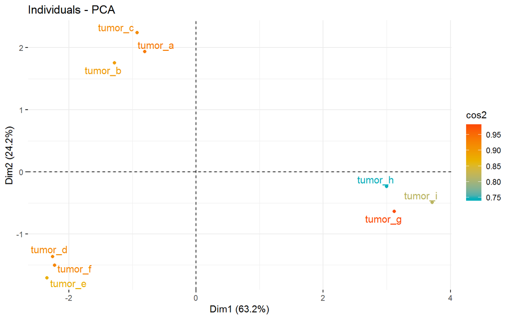

```r
fviz_pca_ind(res.pca3, col.ind = "cos2",
             gradient.cols = c("#00AFBB", "#E7B800", "#FC4E07"),
             repel = TRUE
             )
```

# Las coordenadas, calidad y contribución de las observaciones en las CPs

- El gráfico de barras de las contribuciones nos ayuda a ver qué observaciones contribuyen más a la varianza de las CPs

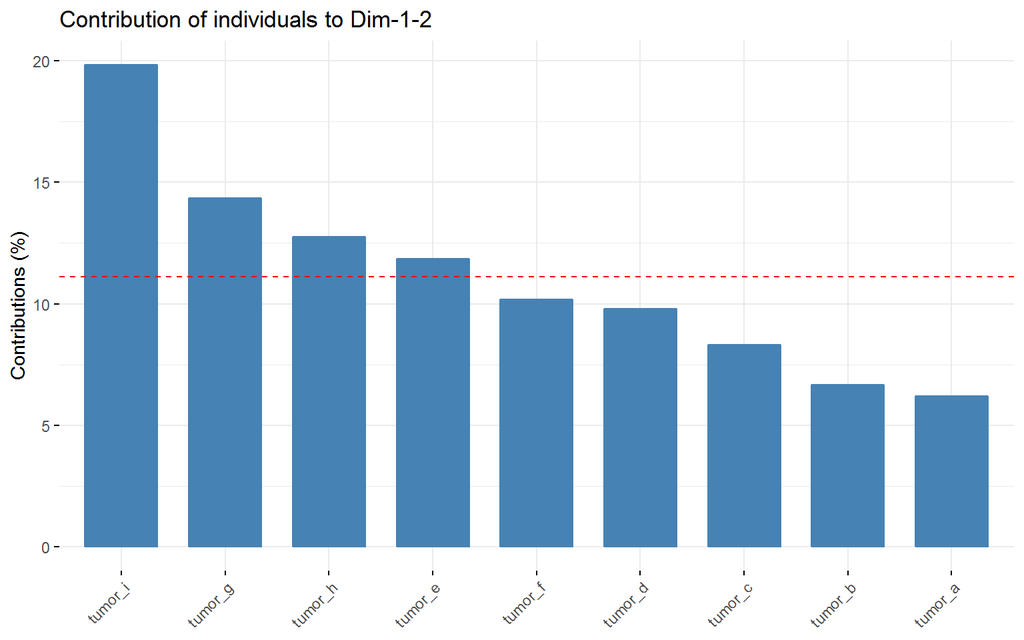

```r
fviz_contrib(res.pca3, choice = "ind", axes = 1:2)
```

- Observamos que `tumor_i`, `tumor_h`, `tumor_g` y `tumor_e` contribuyen a la variabilidad de CP 1 y 2 por encima del promedio esperado

# Análisis conjunto de variables y observaciones (biplot)

- El biplot es un gráfico conjunto de variables y observaciones

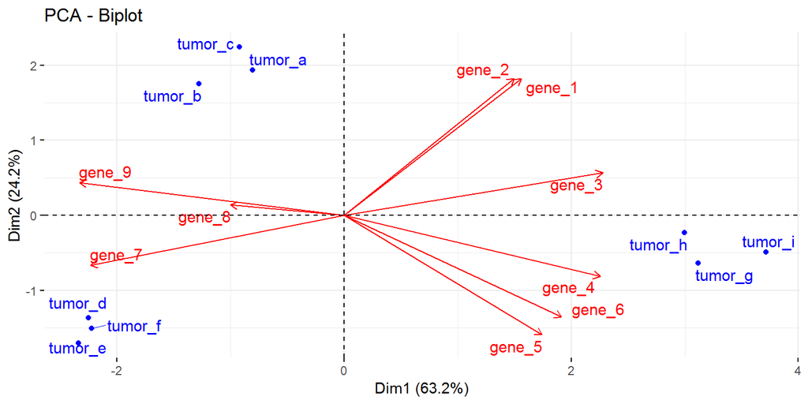

```r
fviz_pca_biplot(res.pca3, repel = TRUE,
                col.var = "red", # Variables color
                col.ind = "blue"  # Individuals color
)
```

- Nos muestra que:
  - Una observación (tumor) que está en el **mismo lado** de una variable dada tiene un valor **alto** en dicha variable.
  - Una observación (tumor) que está en el **lado opuesto** de una variable dada tiene un valor **bajo** en dicha variable.
- En general, con respecto al CP1, vemos que `tumor_g`, `tumor_h` y `tumor_i` tienen mayor expresión en los genes_1 hasta genes_6 (sobre todo genes_3 y genes_4) frente al resto de tejidos tumorales, que se expresan sobre todo en los genes 7 a 9.
- **FICTICIO**: Supongamos que una mutación de los `genes_1` hasta `genes_6` afecta la producción de una proteína (tiroglobulina) y los `tumor_a` hasta `tumor_f` son tumores diferenciados de la glándula tiroides. Y que la inhibición de los `genes_7` al `gene_9` está relacionada con los `tumor_g`, `tumor_h` y `tumor_i` que son tumores medulares Entonces, la CP1 sería una medida diferenciadora del tipo de cáncer tiroides.
- Por otro lado, en la CP2, las variables que más contribuyen son `gene_1`, `gene_2` y `gene_5`, `gene_6`.
- **FICTICIO**: Aunque la CP1 permite diferenciar el grupo de cánceres de tiroides diferenciados, la CP2 puede ayudar a su vez a discriminar dentro de dicho grupo (por ejemplo, tumores papilares y tumoress foliculares).

# Clustering y PCA

- Podemos combinar una técnica de clustering y representar los grupos en un gráfico de la CP1 vs CP2

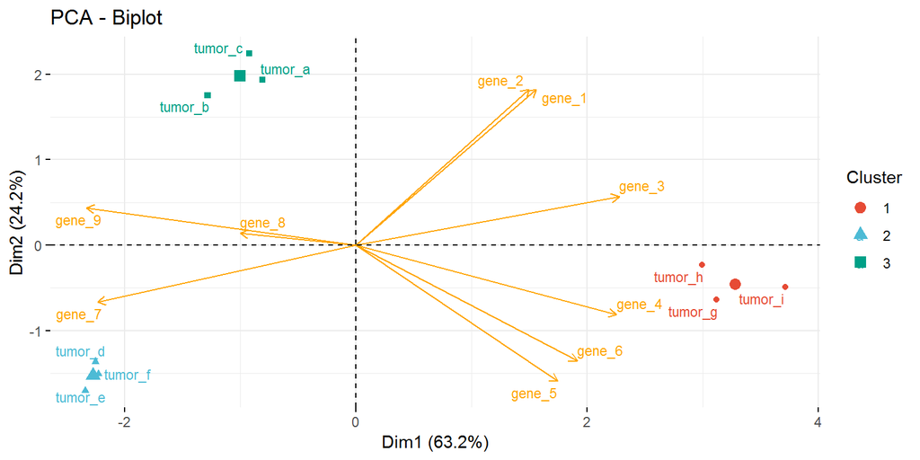

```r
res.clus<-kmeans(datos_trans,centers=3)
datos_trans$cluster<-as.character(res.clus$cluster)

fviz_pca_biplot(res.pca3,
                col.ind=datos_trans$cluster,  labelsize = 3,
                legend.title = "Cluster",
                col.var="orange", repel = TRUE
)+
  ggpubr::fill_palette("jco")+      # Indiviual fill color
  ggpubr::color_palette("npg")      # Variable colors
```

# Añadiendo observaciones suplementarias

- En PCA se pueden añadir a los gráficos observaciones suplementarias y ver cómo se situan con respecto al resto

```r
load("datos_genes_sup.RData")
head(datos_trans_sup)
```

```
##             gene_1     gene_2     gene_3     gene_4     gene_5      gene_6
## tumor_X  1.3635603  1.3517977  0.1438349 -0.4028550 -0.9423331 -1.07708836
## tumor_Z  0.8611755  0.9806914  1.3573247  0.5643000  0.9766244  0.98541337
## tumor_a  0.8726627  1.3464477  0.1580743 -0.5027416 -0.7587607 -1.01691819
## tumor_b  0.8806472  0.7498311 -0.3363201 -0.5912593 -0.8634414 -1.04780750
## tumor_c  1.3893236  1.2426073 -0.1222758 -0.5823842 -1.2881362 -0.85190531
## tumor_d -0.8234644 -1.3032958 -0.6156777 -0.3855728 -0.3429790  0.07098378
##             gene_7     gene_8     gene_9
## tumor_X  0.1105114  0.2871517  0.7620627
## tumor_Z -0.9253193 -0.7364247 -0.7269475
## tumor_a  0.1126525  0.3230032  1.0846077
## tumor_b -0.2406702  0.7023894  1.1404019
## tumor_c  0.3247319  0.2060210  0.7595605
## tumor_d  1.0210364  0.6974373  0.9916284
```

# Añadiendo observaciones suplementarias

- Veamos los gráficos de representación de individuos y el biplot

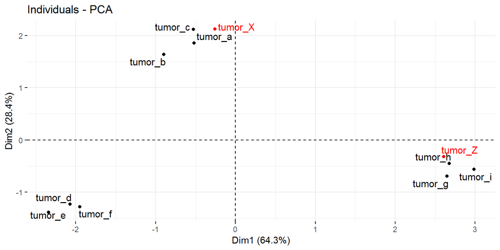

```r
datos_trans_sup$cluster<-c(rep(NA,2),datos_trans$cluster)

# ajustamos PCA indicando las observaciones suplementarias
res.pca4 <- PCA(as.matrix(scale(datos_trans_sup[,-10],scale=FALSE)), ncp=9, scale.unit=FALSE, graph = FALSE,
                ind.sup=1:2)
# plot individuos + obs. suplementarias
fviz_pca_ind(res.pca4, col.ind.sup = "red", repel = TRUE)
```

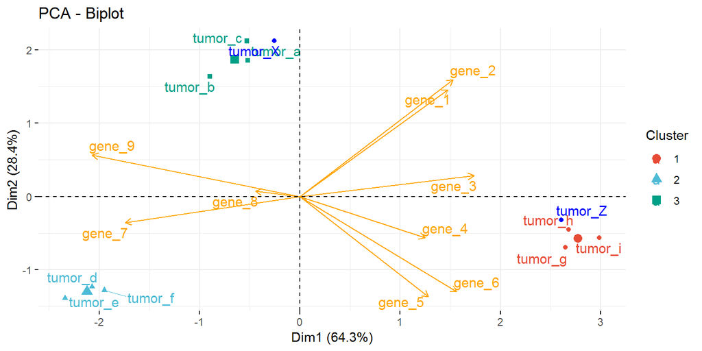

```r
# biplot + obs. suplementarias
fviz_pca_biplot(res.pca4, col.ind.sup = "blue",
                col.ind=datos_trans_sup$cluster[-c(1:2)],
                legend.title = "Cluster",
                col.var="orange", repel = TRUE
)+
  ggpubr::fill_palette("jco")+      # Indiviual fill color
  ggpubr::color_palette("npg")      # Variable colors
```

# Ejercicio práctico

- Practiquemos con un ejercicio práctico

# Ejercicio práctico

[output not shown]

```r
datos.eset <- url("https://github.com/cpgonzal/cursoBioPCA/blob/master/datos_eset.RData?raw=true")
load(datos.eset)
head(small.eset)
```

# Ejercicio práctico

- Observar que las filas del conjunto de datos son los genes y las columnas son las muestras. Podemos trasponer la mtriz para situar en columnas los genes.

```r
small.eset<-as.data.frame(t(small.eset))
```

- Podemos aplicar los tests de esfericidad y el KMO

```r
cortest.bartlett(..., n=...)
KMO(....)
```

- Veamos la dispersión de las variables

```r
df_box<-small.eset %>%
  gather(key=gene, value = expresion)
boxplot(...., ..... )
```

# Ejercicio práctico

- Obtenemos las PCA aplicando cualquiera de los métodos vistos anteriormente

```r
pc <- PCA(....., scale.unit = TRUE, ncp = 2, graph = FALSE)
pc$.....       # autovalores
pc$var$.....   # loadings = autovectores ponderados por autovalor
pc$ind$.....   # puntuaciones factoriales
```

- Veamos la varianza explicada por las CPs

```r
fviz_eig(pc, addlabels = TRUE, ylim = c(0, 100))
```

# Ejercicio práctico

- Analizamos la correlación de variables

```r
pc$var$.....
fviz_pca_var(..., col.var = "red", repel = TRUE)
```

- Recordemos que la correlación al cuadrado (cos2) permiten estudiar las comunalidades, la calidad de la representación en las CPs

```r
pc$var$.....[,1:3]
fviz_???(pc, axes = 1:2,choice = "var")
library("corrplot")
corrplot(pc$var$....[,1:2], is.corr=FALSE,cl.align.text="l")
```

- Incluimos la medida de calidad de la representación en el gráfico de correlación de variables

```r
fviz_pca_var(...., col.var = .....,
             gradient.cols = c("#00AFBB", "#E7B800", "#FC4E07"),
             repel = TRUE
             )
```

# Ejercicio práctico

- La contribución de las variables

```r
corrplot(pc$var$......[,1:5], method = "number",is.corr=FALSE,cl.align.text="l")
fviz_pca_var(...., col.var = ...., repel = TRUE,
             gradient.cols = c("blue", "yellow", "red")
)
```

# Ejercicio práctico

- Los mismos análisis (calidad de representación y contribución) de las observaciones

```r
pc$ind$cos2[,1:4]
fviz_pca_ind(pc, col.ind = "cos2",
             gradient.cols = c("#00AFBB", "#E7B800", "#FC4E07"),
             repel = TRUE
)
```

```r
pc$ind$contrib[,1:4]
fviz_contrib(pc, choice = "ind", axes = 1:2, top = 10)
fviz_pca_ind(pc, col.ind = "contrib",
             gradient.cols = c("blue", "yellow", "red"),
             repel = TRUE
)
```

# Ejercicio práctico

- Finalmente, al hacer el biplot representamos, de forma conjunta, variables y observaciones

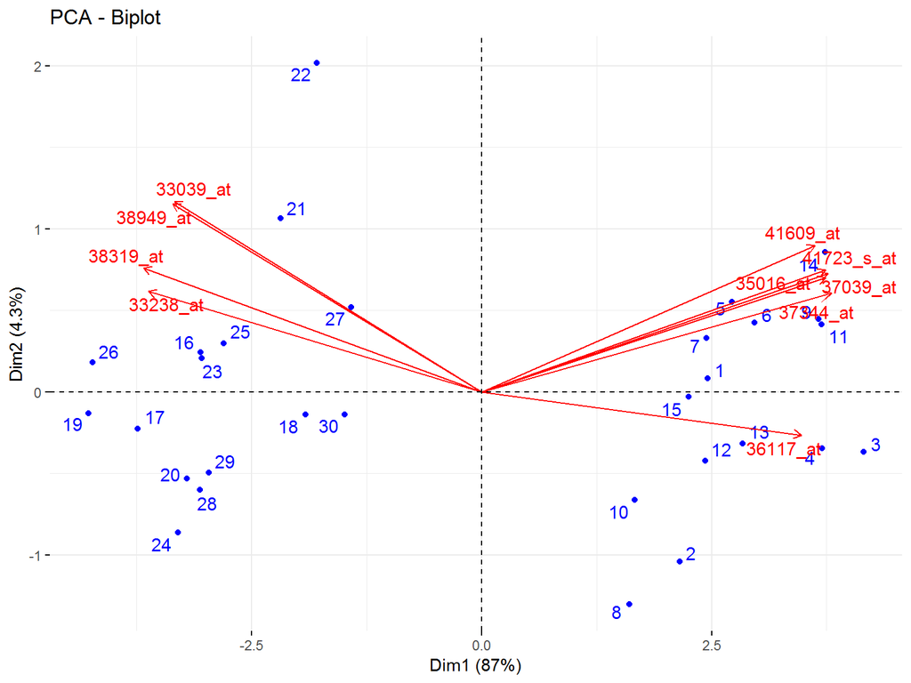

```r
fviz_pca_biplot(pc, repel = TRUE,
                col.var = "red", # Variables color
                col.ind = "blue"  # Individuals color
)
```

# Ejercicio práctico

- Podemos hacer un clustering k-medias de las observaciones y combinar con la PCA

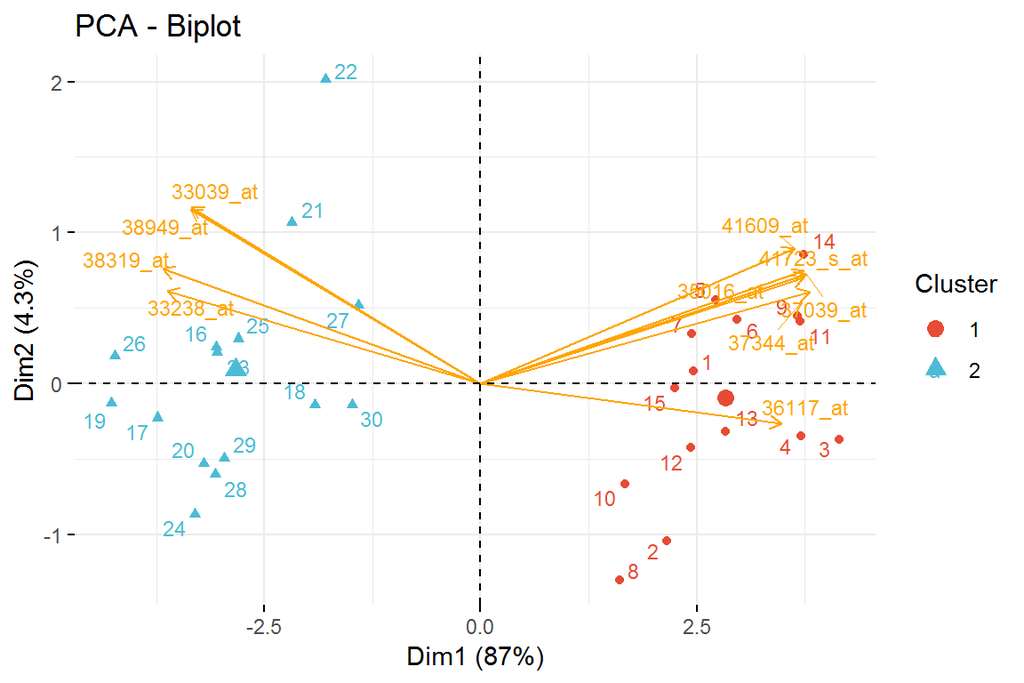

[figure not shown]

```r
small.eset2<-small.eset
res.clus<-kmeans(small.eset2,centers=2)
small.eset2$cluster<-as.character(res.clus$cluster)

# añadir sol. cluster al biplot
fviz_pca_biplot(pc,
                col.ind=small.eset2$cluster,  labelsize = 3,
                legend.title = "Cluster",
                col.var="orange", repel = TRUE
)+ggpubr::fill_palette("jco")+      # Indiviual fill color
  ggpubr::color_palette("npg")      # Variable colors
```

# Extensión del tutorial

- Aunque se ha hablado de la técnica de k-medias, este mini-curso se podría ampliar en un futuro para explicar bien esta técnica y sus posibilidades en genómica

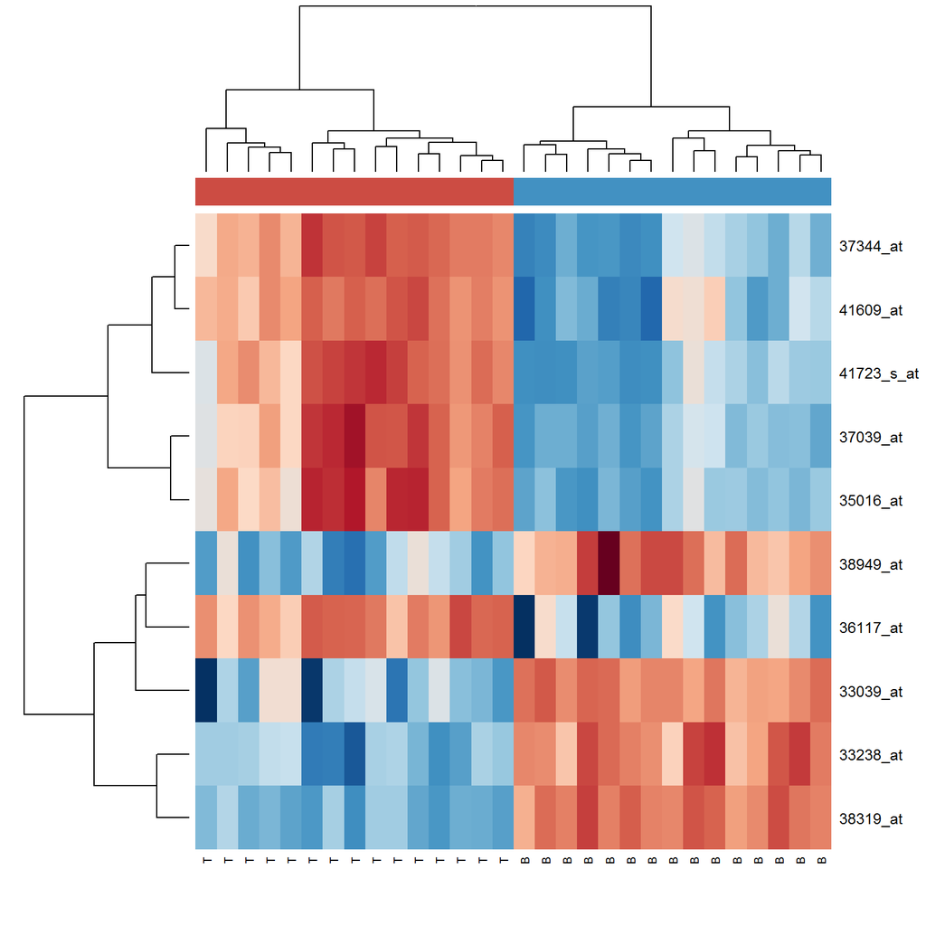